# Replication Weights for Variance Estimation

## Variance Estimation by Simulation

Multiple times you have seen me estimate the variance of an estimator for a specific design via *simulation*. This involves two steps:

1. Apply the sampling design repeatedly ($R$ times) to a population.
2. For each sample, compute the estimate using a given estimator.

We can then approximate the variance as
$$\mbox{V}(\hat\theta) = \frac{1}{R-1}\sum_{r=1}^R(\hat\theta_r -
\bar\theta)^2,$$
where $\hat\theta_r$ is the estimate computed from the $r$-th sample, and
$$\bar\theta = \frac{1}{R}\sum_{r=1}^R \hat\theta_r.$$
But, of course, this is only applicable if we have the entire population.

## Random Group Method

Suppose that rather than conducting a survey to obtain a sample of $n$ elements, we conduct $R$ surveys using the same design that each obtain a sample of $n/R$ elements. Then let
$$\tilde\theta = \frac{1}{R}\sum_{r=1}^R \hat\theta_r,$$
be our estimator of $\theta$, where $\hat\theta_r$ is the estimate from the $r$-th survey. The variance of $\tilde\theta$ can be estimated as
$$\hat{\mbox{V}}(\tilde\theta) =
\frac{1}{R(R-1)}\sum_{r=1}^R(\hat\theta_r - \tilde\theta)^2.$$
A variation on this approach is to obtain one sample using some design, but then attempt to divide the sample into $R$ sub-samples and apply the above.

## Resampling Methods

Resampling methods using some sort of method of sampling from the sample to approximate the variance (or other properties) of the sampling distribution of an estimator.

There are several resampling methods that have been proposed.

1. Bootstrap.
2. Jackknife.
3. Balanced repeated replication.
4. Successive-difference replication.

Rather than listing $R$ samples, we define the samples in terms of $R$ sets of survey weights called *replication weights*.

1. Estimate a parameter of interest $\theta$ with an estimator $\hat\theta$ using the *survey weights*.
2. Estimate the parameter using *each* of $R$ sets of *replication weights*. Call these estimates $\hat\theta_1, \hat\theta_2, \dots, \hat\theta_R$.
3. Approximate the variance of the estimator $\hat\theta$ as
   $$\hat{\mbox{V}}(\hat\theta) = a \sum_{r = 1}^R b_r (\hat\theta_r -
   \hat\theta)^2,$$
   where $a$ and $b_r$ are scale factors that depend on the type of replication weights used.

The above steps could be done using something as simple as a spreadsheet, but specialized software will streamline the calculation.

## Example: American Community Survey (ACS)

Load R packages.

```r
library(tidyverse)
library(tidycensus)
library(tigris)
library(srvyr)
```

Enter API key (get your own).

```r
census_api_key("key goes here")
```

Download microdata.

```r
pnw_microdata <- get_pums(variables = c("HISPEED","FINCP","PUMA"),
  survey = "acs5", year = 2023, state = c("ID","WA","OR"),
  rep_weights = "housing", recode = TRUE) |> rename_with(tolower)
```

Here we can sample a few households to see some of the variables of interest as well as the survey weights (`wgtp`) and the first few (out of 80) replication weights (`wgtp1` through `wgtp80`).

```r
set.seed(123)
pnw_microdata |> slice_sample(n = 10) |>
  select(state_label, hispeed_label, puma, wgtp, wgtp1:wgtp5)
```

```
# A tibble: 10 × 9
   state_label   hispeed_label         puma   wgtp wgtp1 wgtp2 wgtp3 wgtp4 wgtp5
   <ord>         <ord>                 <chr> <dbl> <dbl> <dbl> <dbl> <dbl> <dbl>
 1 Washington/WA Yes                   23312    47    64    81    16    52    15
 2 Idaho/ID      Yes                   00500     9    10    11    11     9    16
 3 Washington/WA Yes                   26102    15    26    14    16     5    26
 4 Oregon/OR     N/A (GQ/vacant/no pa… 09100     1     3     3     3     2     3
 5 Washington/WA Yes                   20501    12    14    19    18     4    16
 6 Washington/WA Yes                   23304    12    14    13     3    18    12
 7 Washington/WA Yes                   23306    14    13    21    17    13    12
 8 Oregon/OR     Yes                   03905    11    11    10    18    20     4
 9 Washington/WA Yes                   26106    10    17    18     3    11    10
10 Washington/WA Yes                   20502    14     4    30    13     3    14
```

Create survey design object by specifying the survey weights and replication weights.

```r
pnw_design <- pnw_microdata |>
  as_survey_rep(weights = wgtp, repweights = wgtp1:wgtp80,
    type = "ACS", mse = TRUE)
```

Domain means for household income by state and whether or not they have hi-speed internet.

```r
pnw_design |> group_by(state_label, hispeed_label) |>
  filter(hispeed_label %in% c("Yes","No")) |>
  summarise(meanfinc = survey_mean(fincp))
```

```
# A tibble: 6 × 4
# Groups:   state_label [3]
  state_label   hispeed_label meanfinc meanfinc_se
  <ord>         <ord>            <dbl>       <dbl>
1 Idaho/ID      Yes             87260.       1026.
2 Idaho/ID      No              66953.       1363.
3 Oregon/OR     Yes             87049.        597.
4 Oregon/OR     No              56730.       1491.
5 Washington/WA Yes            109212.        535.
6 Washington/WA No              65756.       1031.
```

Here is how we can get domain estimates for the proportion of households with hi-speed internet for each PUMA and make a geographic plot. First I will obtain the domain estimates.

```r
pnw_hispeed <- pnw_design |> group_by(state, puma) |>
  summarise(meanfinc = survey_mean(hispeed_label == "Yes"))
```

Next I need to download geometry data for the plot.

```r
fips <- as.numeric(unique(pnw_microdata$state))
geom <- vector(mode = "list", length = length(fips))
for (i in 1:length(geom)) {
  geom[[i]] <- pumas(state = fips[i], year = 2023)
}
geom <- geom |> bind_rows() |> rename_with(tolower)
```

Then I merge the domain estimates with the geometry data.

```r
d <- full_join(geom, pnw_hispeed,
  by = c("statefp20" = "state", "pumace20" = "puma"))
```

And then, finally, the plot.

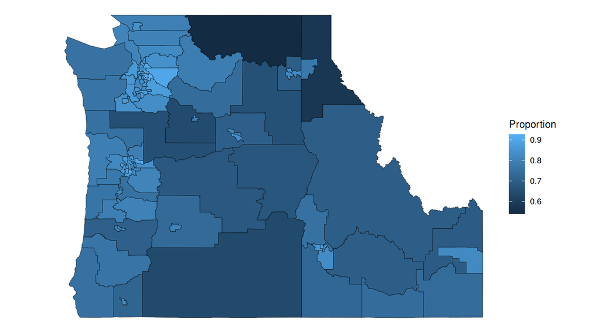

```r
ggplot(d, aes(fill = meanfinc)) + geom_sf() + theme_void() +
  labs(fill = "Proportion")
```